# Worksheet 20: Introduction to Python

Jupyter Notebooks are convenient to organize our code with some text!

### 1. Set up

```python
# IMPORTANT
# Running this chunk lets you have multiple outputs from a single chunk; run it first!
from IPython.core.interactiveshell import InteractiveShell
InteractiveShell.ast_node_interactivity = "all"
```

We will use different packages today but will load them as we learn!

### 2. Basics in Python

Let's first talk about different types of objects and assignments:

```python
# Create an object and print
two = 2
print(two)
```

```
2
```

```python
# Create two objects at once and print
one, four = two - 1, two + two
one
four
```

```
1
```

```
4
```

```python
# Create a list of numbers from 1 to (not including) 7, by 2
x = list(range(1,7,2))
x
```

```
[1, 3, 5]
```

```python
# Some basic built-in functions
len(x)
min(x)
max(x)
type(x)
```

```
3
```

```
1
```

```
5
```

```
list
```

There are 5 main data types:

```python
age_in_years = 34
type(age_in_years)
```

```
int
```

```python
previous_evals = 4.4
type(previous_evals)
```

```
float
```

```python
course = "SDS 322E"
type(course)
```

```
str
```

```python
enjoyed_course = True
type(enjoyed_course)
```

```
bool
```

```python
my_course = [age_in_years, previous_evals, course, enjoyed_course]
type(my_course)
```

```
list
```

Quick indexing in Python is also done using `[]` but since Python begins counting at 0, the first element is at the 0th position. In general, the nth element is located in the (n−1)th position.

```python
my_course[1]
```

```
4.4
```

### 3. Working with NumPy

The package `NumPy` has many built-in functions that we can use when working with data structures. When importing a package, we usually give it a short name. Then we will call functions from this package using the abbreviation:

```python
# Import a new package
import numpy as np

# Create an array (vector)
a = np.array(range(10)) # array is from the numpy package

# take a look
a

# versus
print(a)
```

```
array([0, 1, 2, 3, 4, 5, 6, 7, 8, 9])
```

```
[0 1 2 3 4 5 6 7 8 9]
```

```python
# Operations on elements of arrays
a*2 # multiply by 2
a**2 # square
```

```
array([ 0,  2,  4,  6,  8, 10, 12, 14, 16, 18])
```

```
array([ 0,  1,  4,  9, 16, 25, 36, 49, 64, 81])
```

```python
# Operations on arrays
# sum of elements
np.sum(a)

# mean of elements
np.mean(a)

# standard devaition of a list of elements
np.std(a)
```

```
45
```

```
4.5
```

```
2.8722813232690143
```

```python
# Your turn!

# In a team of 3, create an array, called food, that contains the cost of each member's last meal.
food = np.array([14, 14, 10])

# Index this array to show how much your last meal cost
food[0]

# Find the average cost of a meal in your group
np.mean(food)
```

```
14
```

```
12.666666666666666
```

### 4. Working with pandas

Objects in `pandas` can be thought as enhanced versions of `numpy` structured arrays in which the rows and columns are identified with labels rather than integer indices.

```python
# Import a new package
import pandas as pd

# Create a data frame
df = pd.DataFrame([{'a': 1, 'b': 2}, {'a': 3, 'b': 4}])
df

# Look at the rows
df.index

# Look at the columns
df.columns
```

|  | a | b |
| --- | --- | --- |
| 0 | 1 | 2 |
| 1 | 3 | 4 |

```
RangeIndex(start=0, stop=2, step=1)
```

```
Index(['a', 'b'], dtype='object')
```

```python
# Your turn!

# In a team of 3, create a data frame:
# one column called "name" contains the name of each member
# another column called "meal" contains the type of meal they had last
# another column called "cost" contains the cost of their last meal

# Index the data frame to only keep the cost
food = pd.DataFrame([{'name': "Steven", 'cost': 14}, {'name': "Angelina", 'cost': 14}, {'name': "Brian", 'cost': 20}])
food
food['cost']
```

|  | name | cost |
| --- | --- | --- |
| 0 | Steven | 14 |
| 1 | Angelina | 14 |
| 2 | Brian | 20 |

```
0    14
1    14
2    20
Name: cost, dtype: int64
```

We'll talk more about pandas with data wrangling.

### 5. Visualization with matplotlib and seaborn

`seaborn` is a library for making statistical graphics in Python. It builds on top of `matplotlib` and integrates closely with pandas data structures.

```python
# Import new packages
import matplotlib.pyplot as plt
import seaborn as sns

import ssl
ssl._create_default_https_context = ssl._create_unverified_context
```

```python
# Load dataset from library
iris = sns.load_dataset("iris")

# Take a peek: looks familiar?
iris.head()
```

|  | sepal_length | sepal_width | petal_length | petal_width | species |
| --- | --- | --- | --- | --- | --- |
| 0 | 5.1 | 3.5 | 1.4 | 0.2 | setosa |
| 1 | 4.9 | 3.0 | 1.4 | 0.2 | setosa |
| 2 | 4.7 | 3.2 | 1.3 | 0.2 | setosa |
| 3 | 4.6 | 3.1 | 1.5 | 0.2 | setosa |
| 4 | 5.0 | 3.6 | 1.4 | 0.2 | setosa |

```
<BarContainer object of 3 artists>
```

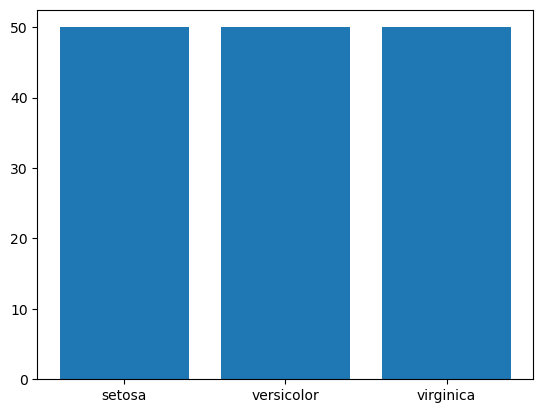

```python
# Create a bar graph
counts = iris['species'].value_counts() # find counts
plt.bar(counts.index, counts.values)
```

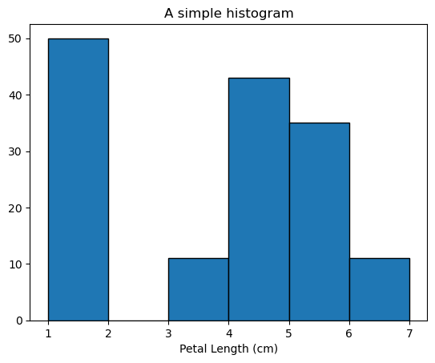

```python
# Create a histogram
plt.hist(x = iris['petal_length'], bins = [1,2,3,4,5,6,7], edgecolor="black")
plt.xlabel('Petal Length (cm)') # label x-axis
plt.title('A simple histogram') # give a title
```

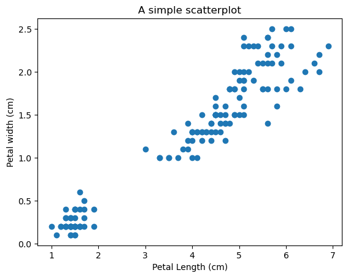

```python
# Create a scatterplot
plt.plot(iris['petal_length'], iris['petal_width'], linestyle = 'none', marker = 'o')
plt.xlabel('Petal Length (cm)') # label x-axis
plt.ylabel('Petal width (cm)') # label y-axis
plt.title('A simple scatterplot') # give a title
```

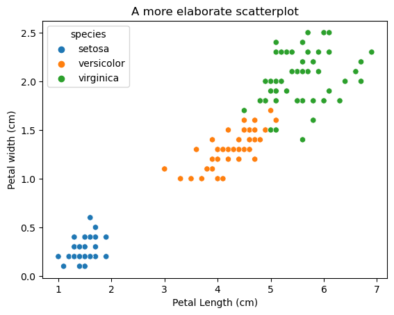

```python
# Seaborn is a more versatile data visualization package
sns.scatterplot(x="petal_length", y="petal_width", data=iris, hue='species')
plt.xlabel('Petal Length (cm)') # label x-axis
plt.ylabel('Petal width (cm)') # label y-axis
plt.title('A more elaborate scatterplot') # give a title
```

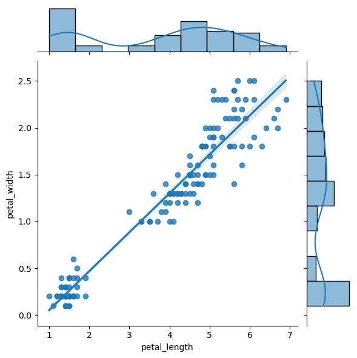

```python
# Join different plots into one!
sns.jointplot(x="petal_length", y="petal_width", data=iris, kind='reg')
```

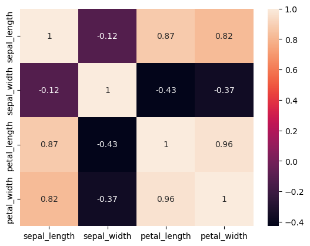

```python
# Look at the strneght of the relationships between the variables with a correlation matrix
sns.heatmap(iris.corr(), annot=True)
```

A very useful website to decide on appropriate visualizations and how to make them in Python: https://www.python-graph-gallery.com/